# 1. Stabilisation des données Navigo

## 4.2. Test sur le port de Tonnay-Charente

```
Destinations selon navigo (en tonneaux) :
           destination  tonnage
0           Angleterre   5541.0
1  Etats de l'Empereur    482.0
2             Hollande     44.0
3             Danemark     98.0
4             Portugal     47.0
Ports pris en compte pour le bureau : Charente
Tonnage moyen des navires : 103.53333333333333
```

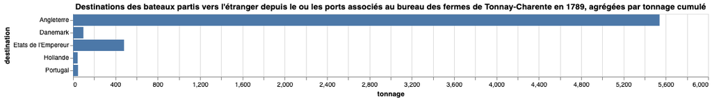

```
scan des valeurs pour le bureau des fermes de Tonnay-Charente
flux bruts toflit18 :
            partenaire        valeur
0             Portugal  4.134053e+04
1           Angleterre  4.548521e+06
2             Hollande  1.633188e+04
3  Villes hanséatiques  6.591877e+04
4  Etats de l'Empereur  4.003226e+05
5             Danemark  8.653851e+04
```

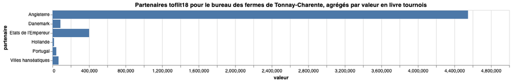

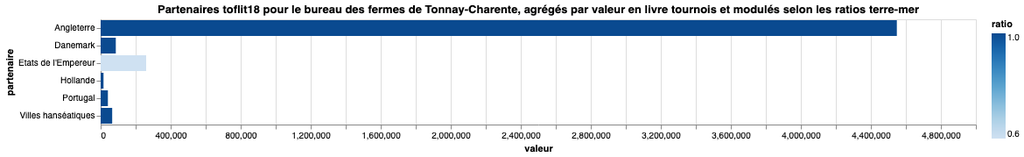

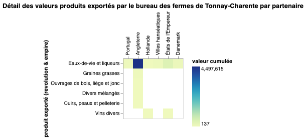

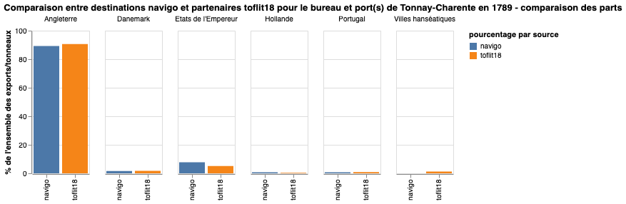

```
Correspondance résumé :
                         partner  sum_tonnage   sum_exports  price_per_barrel
0                       Danemark      33049.0  6.334500e+06        191.669945
1                     Angleterre      57563.0  3.420050e+07        594.140333
2                         Russie      14848.0  6.630000e+06        446.524784
3                        Espagne      59250.0  3.283826e+07        554.232315
4                       Hollande      78214.0  3.357150e+07        429.226225
5                       Portugal      14007.0  3.935200e+06        280.945242
6            Villes hanséatiques      68277.0  6.019470e+07        881.624852
7                          Suède      14161.0  5.053700e+06        356.874515
8          États-Unis d'Amérique      22271.0  2.050600e+06         92.074896
9                      Allemagne      28703.0  2.246440e+07        782.649897
10                        Prusse      20644.0  9.008500e+06        436.373765
11          Royaume de Sardaigne      18869.0  9.191349e+06        487.113755
12                         Gênes      38779.0  6.286100e+06        162.100621
13  Milanais, Toscane et Lucques      10210.0  1.084710e+07       1062.399608
14         États ecclésiastiques       3531.0  3.421400e+06        968.960634
15                        Naples      21383.0  5.355600e+06        250.460646
16                        Venise       1161.0  8.947000e+05        770.628768
17    Empire Ottoman et Barbarie      45285.0  2.560810e+07        565.487468
```

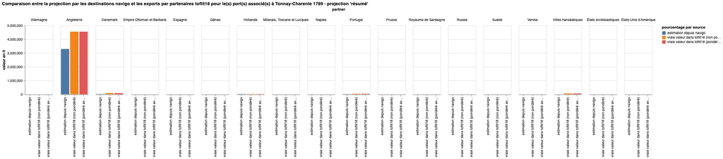

```
Total des exports en lt selon la projection 'résumé' : 3,343,005 lt
Total des exports en lt selon toflit18 : 5,158,973 lt
Total des exports en lt selon toflit18 (corrigé avec ratios terre-mer) : 5,018,691 lt
Méthode 'résumé' - rapport projection/réalité : facteur de 0.6661110006337072
```

Première analyse : les résultats de la projection sont ici plutôt proches de la réalité décrite par toflit18 : elle les sous-estime de 34%.

Hypothèse d'explication :

- l'ensemble des flux de navires concernant Angleterre, on peut supposer que les exports de Tonnay-Charentes correspondent de manière proche au commerce de la France avec la GB en général ?

## 4.3 Test sur la direction des fermes de La Rochelle et tous ses ports associés

```
Destinations selon navigo (en tonneaux) :
             destination  tonnage
0             Angleterre  12586.0
1    Etats de l'Empereur   1378.0
2                 Prusse   3696.0
3               Hollande   6639.0
4    Villes hanséatiques   4588.0
5  États-Unis d'Amérique   3038.0
6               Danemark   4915.0
7                Espagne    902.0
8               Portugal   1351.0
9                 Russie    386.0
Ports pris en compte pour le bureau : Saint Martin de Ré, Mortagne, Marennes, Charente, Noirmoutier, Rochefort, Saint Gilles sur Vie, Ars en Ré, La Flotte en Ré, La Rochelle
Tonnage moyen des navires : 129.01633986928104
```

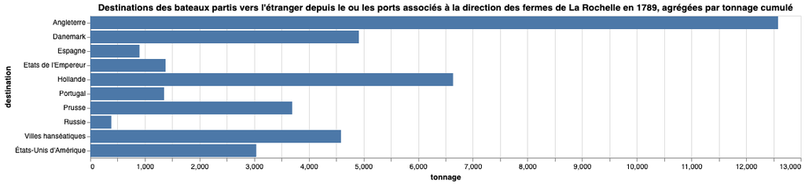

```
scan des valeurs pour la direction des fermes de La Rochelle
flux bruts toflit18 :
               partenaire        valeur
0     Monde hors colonies  5.136098e+06
1                 Espagne  3.845865e+04
2              Angleterre  4.881322e+06
3                Portugal  4.134053e+04
4                Hollande  1.615313e+05
5     Villes hanséatiques  5.422232e+05
6     Etats de l'Empereur  4.106972e+05
7                Danemark  2.882633e+05
8                  Prusse  5.127063e+04
9   États-Unis d'Amérique  5.352916e+04
10                 Russie  2.303400e+04
11                  Suède  6.009984e+03
12                Sénégal  1.591040e+06
13         Saint-Domingue  7.141800e+04
14                  Indes  3.806000e+04
Problème d'attribution du le partenaire qui n'est pas dans la table des ratios terre-mer :  Monde hors colonies
Problème d'attribution du le partenaire qui n'est pas dans la table des ratios terre-mer :  Sénégal
Problème d'attribution du le partenaire qui n'est pas dans la table des ratios terre-mer :  Indes
```

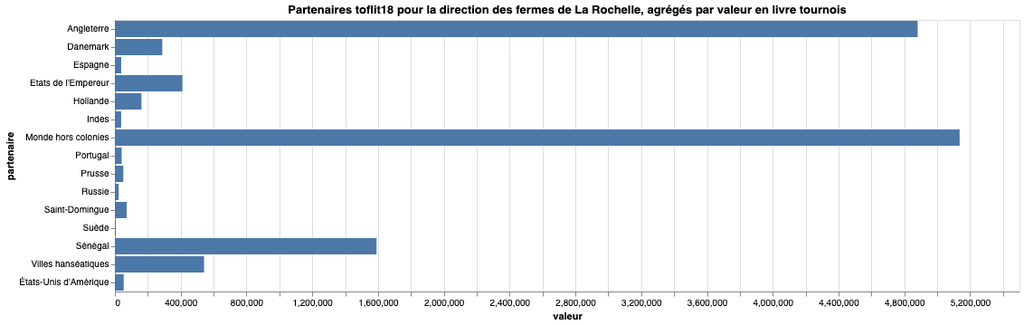

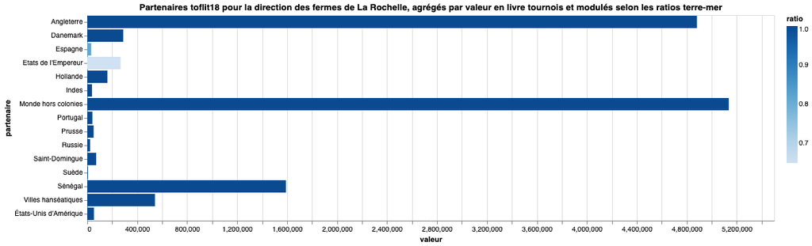

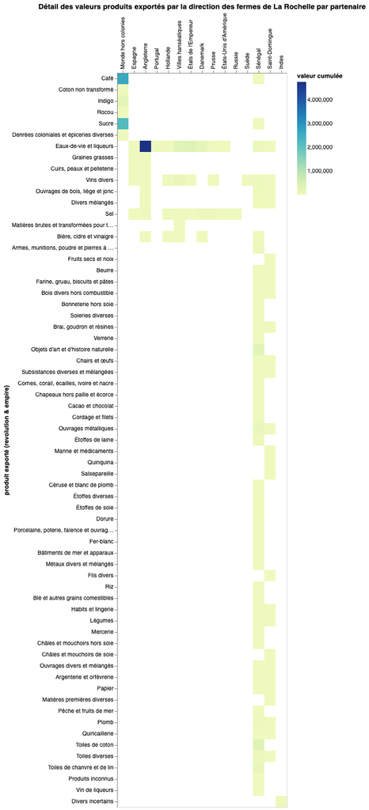

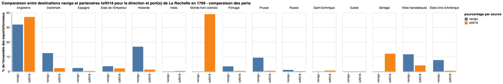

```
Correspondance résumé :
                         partner  sum_tonnage   sum_exports  price_per_barrel
0                       Danemark      33049.0  6.334500e+06        191.669945
1                     Angleterre      57563.0  3.420050e+07        594.140333
2                         Russie      14848.0  6.630000e+06        446.524784
3                        Espagne      59250.0  3.283826e+07        554.232315
4                       Hollande      78214.0  3.357150e+07        429.226225
5                       Portugal      14007.0  3.935200e+06        280.945242
6            Villes hanséatiques      68277.0  6.019470e+07        881.624852
7                          Suède      14161.0  5.053700e+06        356.874515
8          États-Unis d'Amérique      22271.0  2.050600e+06         92.074896
9                      Allemagne      28703.0  2.246440e+07        782.649897
10                        Prusse      20644.0  9.008500e+06        436.373765
11          Royaume de Sardaigne      18869.0  9.191349e+06        487.113755
12                         Gênes      38779.0  6.286100e+06        162.100621
13  Milanais, Toscane et Lucques      10210.0  1.084710e+07       1062.399608
14         États ecclésiastiques       3531.0  3.421400e+06        968.960634
15                        Naples      21383.0  5.355600e+06        250.460646
16                        Venise       1161.0  8.947000e+05        770.628768
17    Empire Ottoman et Barbarie      45285.0  2.560810e+07        565.487468
```

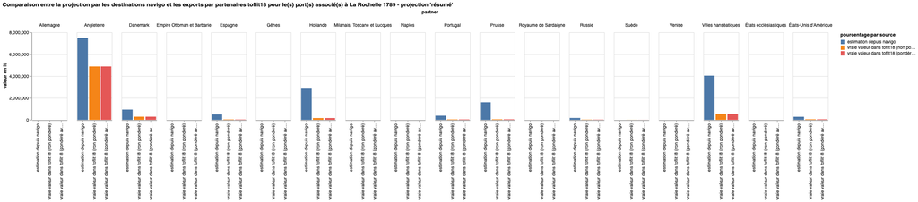

```
Total des exports en lt selon la projection 'résumé' : 18,258,829 lt
Total des exports en lt selon toflit18 : 13,334,295 lt
Total des exports en lt selon toflit18 (corrigé avec ratios terre-mer) : 13,183,366 lt
Méthode 'résumé' - rapport projection/réalité : facteur de 1.3849899690270715
```

Première analyse : à l'échelle de la direction des fermes, les résultats sont assez proches de la réalité décrite par toflit18 : ils sont surestimés de 38%.

## 4.4. Bilan des tests sur la projection

La projection fonctionne de manière inégale suivant les corpus sur lesquels elle est testée.

Des spécificités font-elles que la projection fonctionne mieux sur certaines zones que d'autres ?

Malgré le caractère décevant et incertain de ces tests, on va néanmoins tenter de projeter le modèle sur le cas de Dunkerque en 1789.

# 5. projection sur Dunkerque 1789

On va maintenant projeter les prix par tonneau/partenaire sur les tonnages partis de Dunkerque, puis les comparer aux données toflit18 partielles dont on dispose sur le commerce colonial.

Pour le cas particulier de l'Angleterre, on va supprimer les bateaux de 12 tonneaux afin de ne pas compter les smoggleurs, pour lesquels on dispose par ailleurs d'estimations plus fiables.

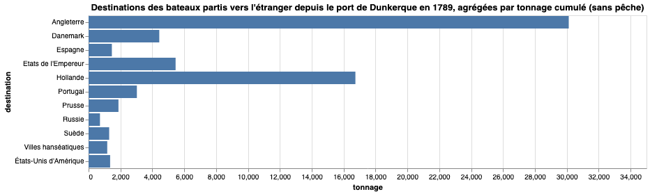

```
tonnage cumulé 67650.0
nombre de trajets :  837
nombre de trajets vers l'angleterre par smoggleurs :  1144
```

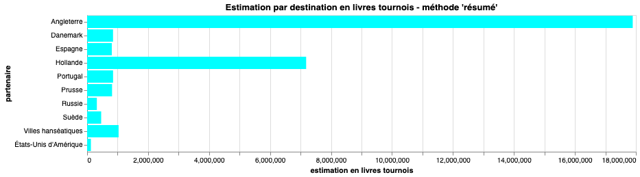

```
valeur d'export vers l'étranger estimée pour Dunkerque selon la méthode 'résumé' : 30,347,553 livres tournois
```

On estime donc la valeur d'export de Dunkerque à 30 milions de lt (plus les 3.3 milions de LT de smoggleurs).

Les autres destinations des navires partis de Dunkerque sont plus ou moins "égalisées" par le jeu des prix par tonneaux, notamment le Danemark, le Portugal, la Prusse et les États-Unis qui voient leur part d'exports réduite par rapport à leur part de navigation.

On compare maintenant les projections obtenues aux exports connus par toflit18, qui correspondent aux exports de produits coloniaux et aux exports vers les colonies.

```
exports :
            partenaire     valeur
0  Monde hors colonies  4560525.0
1       Saint-Domingue   388838.0
2               Tobago   373782.0
3           Martinique   573101.0
4           Guadeloupe    29245.0
5    Guinée et Sénégal    46162.0
6    Cayenne et Guyane      375.0
imports hors France :
                       partenaire      valeur
0             Villes hanséatiques   1467759.0
1                        Hollande   7196299.0
2                      Angleterre  14937716.0
3             États de l'Empereur   4022285.0
4   Îles françaises de l'Amérique   8670155.0
5             Milanais et Toscane    254665.0
6           États-Unis d'Amérique   1479188.0
7                          Prusse   1308952.0
8             Danemark et Norvège    162839.0
9                         Espagne   1767338.0
10                         Russie    238265.0
11                          Suède    699910.0
12                       Portugal     53067.0
13                          Gênes    493638.0
14                         Venise    113330.0
15                      Sardaigne     66534.0
```

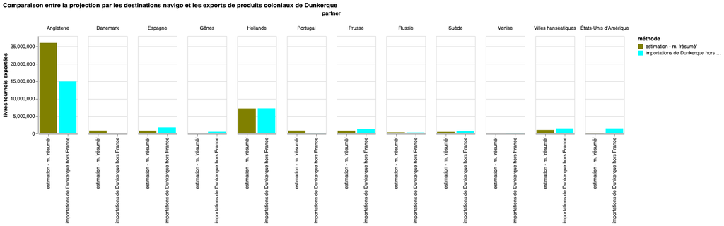

```
somme imports Dunkerque : 42,931,940 lt
somme imports français depuis Dunkerque : 4,095,464 lt
somme exports coloniaux : 5,972,028 lt
somme exports selon la projection résumé : 38,503,911 lt
```

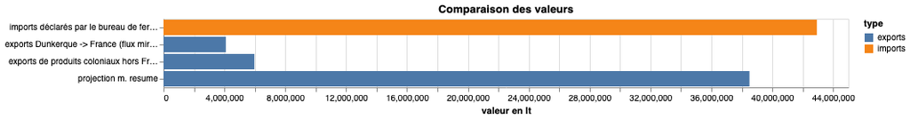

# Conclusion

Pour rappel, la méthode a consisté à :

- établir un prix par tonneau et par destination, en estimant les valeurs d'export de la France par la mer seule et les flux navigo par tonnage - pour l'année 1787
- pour les tests : d'une part sommer les flux toflit18 et les pondérer par destination en fonction des ratio terre-mer tels que décrits en 1787, d'autre part sommer les flux navigo par destination en tonnage cumulé puis les transformer en valeur via l'index des prix par tonneau par destination
- pour Dunkerque : sommer les flux navigo par destination en tonnage cumulé puis les transformer en valeur via l'index des prix par tonneau par destination